# Identifying matching patterns in multiple datasets

Xulong Wang

September 2, 2015

##### This document describes methods to identify matching patterns in multiple datasets.

```r
load("~/Dropbox/GitHub/MCA/nci60.rdt")
str(nci60)
```

```
## List of 2
##  $ rna    : num [1:9690, 1:59] 2.65 6.74 4.62 6.37 4.88 ...
##   ..- attr(*, "dimnames")=List of 2
##   .. ..$ : chr [1:9690] "A2M" "AACS" "AAED1" "AAGAB" ...
##   .. ..$ : chr [1:59] "BR.MCF7" "BR.MDA_MB_231" "BR.HS578T" "BR.BT_549" ...
##  $ protein: num [1:94, 1:59] -1.67 2.73 1.65 3.54 -1.67 ...
##   ..- attr(*, "dimnames")=List of 2
##   .. ..$ : chr [1:94] "ACVR2A" "ADNP" "AKAP5" "AKAP8" ...
##   .. ..$ : chr [1:59] "BR.MCF7" "BR.MDA_MB_231" "BR.HS578T" "BR.BT_549" ...
```

```r
load("~/Dropbox/GitHub/Lupus/Immgen/immgenList.rdt") # version:20150811
immgen <- immgenList$immgen # 224 transcriptome
dim(immgen)
```

```
## [1] 21755   224
```

```r
(type <- gsub("_.*", "", names(immgen)))
```

```
##   [1] "SC"   "SC"   "SC"   "SC"   "SC"   "SC"   "SC"   "SC"   "SC"   "SC"
##  [11] "SC"   "SC"   "MLP"  "MLP"  "proB" "proB" "proB" "preB" "preB" "B"
##  [21] "proB" "proB" "proB" "preB" "B"    "B"    "B"    "B"    "B"    "B"
##  [31] "B"    "B1a"  "B"    "B"    "B"    "B"    "B1b"  "B1a"  "DC"   "DC"
##  [41] "DC"   "DC"   "DC"   "DC"   "DC"   "DC"   "DC"   "DC"   "DC"   "DC"
##  [51] "DC"   "DC"   "DC"   "DC"   "DC"   "DC"   "DC"   "DC"   "DC"   "DC"
##  [61] "DC"   "DC"   "DC"   "DC"   "DC"   "DC"   "DC"   "DC"   "DC"   "DC"
##  [71] "DC"   "DC"   "DC"   "DC"   "MF"   "MF"   "MF"   "MF"   "MF"   "MF"
##  [81] "MF"   "MF"   "MF"   "MF"   "MF"   "MF"   "MF"   "MF"   "MF"   "Mo"
##  [91] "Mo"   "Mo"   "Mo"   "Mo"   "Mo"   "Mo"   "Mo"   "GN"   "GN"   "GN"
## [101] "GN"   "GN"   "GN"   "preT" "preT" "preT" "preT" "preT" "preT" "preT"
## [111] "preT" "preT" "T"    "T"    "T"    "T"    "T"    "T"    "T"    "T"
## [121] "T"    "T"    "T"    "T"    "T"    "T"    "T"    "T"    "T"    "T"
## [131] "T"    "T"    "T"    "T"    "T"    "T"    "T"    "T"    "T"    "T"
## [141] "T"    "T"    "T"    "T"    "T"    "T"    "T"    "T"    "T"    "T"
## [151] "T"    "T"    "T"    "T"    "T"    "T"    "T"    "T"    "T"    "T"
## [161] "T"    "T"    "T"    "NKT"  "NKT"  "NKT"  "NKT"  "NKT"  "NKT"  "NKT"
## [171] "Tgd"  "Tgd"  "Tgd"  "Tgd"  "Tgd"  "Tgd"  "Tgd"  "Tgd"  "Tgd"  "Tgd"
## [181] "Tgd"  "Tgd"  "Tgd"  "Tgd"  "Tgd"  "Tgd"  "Tgd"  "Tgd"  "Tgd"  "Tgd"
## [191] "Tgd"  "Tgd"  "Ep"   "Fi"   "Fi"   "FRC"  "FRC"  "LEC"  "LEC"  "BEC"
## [201] "BEC"  "St"   "NK"   "NK"   "NK"   "NK"   "NK"   "NK"   "NK"   "NK"
## [211] "NK"   "NK"   "NK"   "NK"   "NK"   "NK"   "NK"   "ILC1" "ILC1" "ILC1"
## [221] "ILC2" "ILC3" "ILC3" "ILC3"
```

```r
(tissue <- gsub(".*_", "", names(immgen)))
```

```
##   [1] "BM"     "BM"     "BM"     "FL"     "FL"     "BM"     "BM"
##   [8] "BM"     "BM"     "BM"     "BM"     "BM"     "BM"     "FL"
##  [15] "BM"     "BM"     "BM"     "BM"     "BM"     "BM"     "FL"
##  [22] "FL"     "FL"     "FL"     "FL"     "Sp"     "Sp"     "Sp"
##  [29] "Sp"     "Sp"     "Sp"     "Sp"     "BM"     "MLN"    "LN"
##  [36] "PC"     "PC"     "PC"     "Th"     "Th"     "Sp"     "Sp"
##  [43] "Sp"     "Sp"     "Sp"     "Sp"     "SLN"    "SLN"    "SLN"
##  [50] "SLN"    "SLN"    "SLN"    "SLN"    "SLN"    "SLN"    "MLN"
##  [57] "MLN"    "MLN"    "MLN"    "MLN"    "Sk"     "Lv"     "Lv"
##  [64] "LuLN"   "LuLN"   "Lu"     "Lu"     "Lu"     "Lu"     "Kd"
##  [71] "SI"     "SI"     "SI"     "SI"     "BM"     "Sp"     "Lu"
##  [78] "Lu"     "PC"     "SI"     "SI"     "SI"     "SI"     "PC"
##  [85] "CNS"    "PC"     "PC"     "PC"     "PC"     "BM"     "BM"
##  [92] "Bl"     "Bl"     "Bl"     "Bl"     "Bl"     "LN"     "BM"
##  [99] "Bl"     "BM"     "SynF"   "PC"     "PC"     "Th"     "Th"
```

[output cut: 17 more lines]

To simulate samples with defined signal, we mixed the 34 spleen cells with certain proportions in 10 pools. Corresponding transcriptomes of the 10 pools were built based on the 34 cell transcriptomes and corresponding proportions.

```r
immgen <- immgen[tissue == "Sp"] # only spleen cells
(type <- gsub("_.*", "", names(immgen)))
```

```
##  [1] "B"    "B"    "B"    "B"    "B"    "B"    "B1a"  "DC"   "DC"   "DC"
## [11] "DC"   "DC"   "DC"   "MF"   "T"    "T"    "T"    "T"    "T"    "T"
## [21] "T"    "NKT"  "NKT"  "Tgd"  "Tgd"  "Tgd"  "Tgd"  "Tgd"  "NK"   "NK"
## [31] "NK"   "NK"   "NK"   "NK"   "NK"   "NK"   "NK"   "NK"   "NK"   "NK"
## [41] "NK"   "ILC1"
```

```r
immgen <- immgen[type %in% c("B", "DC", "T", "NK", "NKT")] # refine to major types
(type <- gsub("_.*", "", names(immgen)))
```

```
##  [1] "B"   "B"   "B"   "B"   "B"   "B"   "DC"  "DC"  "DC"  "DC"  "DC"
## [12] "DC"  "T"   "T"   "T"   "T"   "T"   "T"   "T"   "NKT" "NKT" "NK"
## [23] "NK"  "NK"  "NK"  "NK"  "NK"  "NK"  "NK"  "NK"  "NK"  "NK"  "NK"
## [34] "NK"
```

```r
(names(immgen) <- gsub("_Sp", "", names(immgen)))
```

```
##  [1] "B_T1"         "B_T2"         "B_T3"         "B_Fo"
##  [5] "B_GC"         "B_MZ"         "DC_4+"        "DC_8+"
##  [9] "DC_8-4-11b-"  "DC_8-4-11b+"  "DC_pDC_8-"    "DC_pDC_8+"
## [13] "T_4Nve"       "T_4Mem"       "T_4Mem44h62l" "T_4FP3-"
## [17] "T_4FP3+25+"   "T_8Nve"       "T_8Mem"       "NKT_4+"
## [21] "NKT_4-"       "NK"           "NK_49CI-"     "NK_49CI+"
## [25] "NK_49H-"      "NK_49H+"      "NK_MCMV1"     "NK_MCMV7"
## [29] "NK_H+_MCMV1"  "NK_H+_MCMV7"  "NK_b2m-"      "NK_DAP10-"
## [33] "NK_DAP12-"    "NK_CD127-"
```

```r
summary(rowVars(immgen))
```

```
##      Min.   1st Qu.    Median      Mean   3rd Qu.      Max.
##  0.007316  0.037170  0.067780  0.241600  0.171800 15.260000
```

```r
immgen <- immgen[rowVars(immgen) > 0.1, ]

M <- ncol(immgen) # cell number
N <- nrow(immgen) # gene number
P0 <- 10 # sample group number

signal <- rbind( # TRUE signal: adjustable
  T_4Nve = seq(from = 0.1, to = 0.01, length.out = P0),
  T_8Nve = seq(from = 0.1, to = 0.01, length.out = P0),
  T_4Mem = seq(from = 0.01, to = 0.2, length.out = P0),
  T_8Mem = seq(from = 0.01, to = 0.2, length.out = P0)
); colnames(signal) <- paste0("S", 1:P0)

pseudo <- lapply(1:1, function(x) { # replicates
  signal_noise = signal + rnorm(2 * P0, 0.01, 0.01)
  random = rnorm(M * P0, mean = 1/M * 2, sd = 0.02)
  random = matrix(random, nrow = M, ncol = P0)
  random = random[-c(1:4), ]
  rownames(random) = setdiff(names(immgen), rownames(signal))
  X = rbind(signal_noise, random) # M by P0
  X[X < 0] = 0
  X = sweep(X, 2, colSums(X), "/")
  Y = as.matrix(immgen[, rownames(X)]) %*% X # N by P0
  Y = sweep(Y, 2, colSums(Y), "/") * 1e5
  list(X = X, Y = Y)
})

X <- do.call(cbind, lapply(pseudo, function(x) x$X)); dim(X)
```

```
## [1] 34 10
```

```r
Y <- do.call(cbind, lapply(pseudo, function(x) x$Y)); dim(Y)
```

```
## [1] 8377   10
```

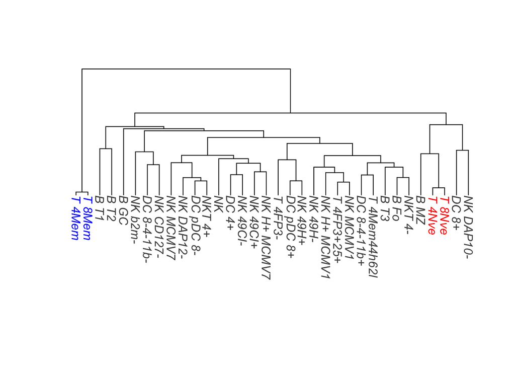

```r
mycol <- c("red", "red", "blue", "blue", rep("grey30", 30))
hcX <- hcluster(X, method = "pearson", link = "average") %>% as.phylo
plot(hcX, direction="downward", tip.col = mycol)
```

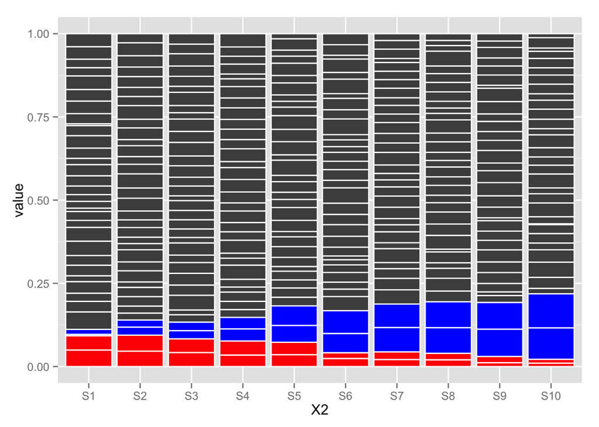

```r
Xg <- melt(X) # graph the patterns
Xg$X2 <- factor(Xg$X2, levels = paste0("S", 1:10))
ggplot(Xg, aes(x = X2, y = value)) + geom_bar(fill = rep(mycol, 10), color = "white", stat = "identity")
```

With simulated pseudo-samples, we want to identify genes that follow the same patterns as cell proportions over the pseudo-samples. These can be signature genes for the corresponding cells.

##### WGCNA

```r
power <- c(c(1:10), seq(12, 20, by = 2))
sft.x <- pickSoftThreshold(t(X), powerVector = power)
```

```
##    Power SFT.R.sq slope truncated.R.sq mean.k. median.k. max.k.
## 1      1   0.0718 -7.20        -0.1930   9.780   9.45000  13.20
## 2      2   0.1670 -5.96         0.0158   4.360   4.12000   7.86
## 3      3   0.2720 -8.61         0.0646   2.390   2.13000   5.54
## 4      4   0.2820 -7.06         0.0797   1.500   1.21000   4.38
## 5      5   0.1650 -4.46        -0.0188   1.040   0.72300   3.77
## 6      6   0.1510 -4.28         0.0898   0.770   0.42800   3.35
## 7      7   0.1990 -4.68         0.0504   0.606   0.26800   3.05
## 8      8   0.1340 -3.65         0.0712   0.497   0.17100   2.81
## 9      9   0.0591 -2.31         0.1670   0.423   0.11100   2.62
## 10    10   0.0776 -2.47         0.0758   0.368   0.07300   2.47
## 11    12   0.1200 -2.76         0.0422   0.296   0.03230   2.21
## 12    14   0.1390 -2.62         0.0253   0.250   0.01470   2.00
## 13    16   0.1180 -2.25         0.1340   0.217   0.00679   1.83
## 14    18   0.1320 -2.18         0.1180   0.192   0.00319   1.68
## 15    20   0.1510 -2.14         0.0882   0.172   0.00151   1.55
```

```r
sft.y <- pickSoftThreshold(t(Y), powerVector = power)
```

```
##    Power SFT.R.sq  slope truncated.R.sq mean.k. median.k. max.k.
## 1      1   0.7280  3.830          0.992  3310.0    3320.0   4450
## 2      2   0.4910  1.450          0.974  1810.0    1780.0   3000
## 3      3   0.1230  0.423          0.925  1140.0    1090.0   2220
## 4      4   0.0172 -0.129          0.867   784.0     732.0   1740
## 5      5   0.2080 -0.463          0.857   568.0     515.0   1410
## 6      6   0.3950 -0.707          0.864   429.0     377.0   1170
## 7      7   0.5010 -0.889          0.857   334.0     285.0    989
## 8      8   0.5820 -1.010          0.875   266.0     221.0    848
## 9      9   0.6350 -1.090          0.890   216.0     173.0    735
## 10    10   0.6790 -1.150          0.902   179.0     139.0    644
## 11    12   0.7180 -1.260          0.907   127.0      92.6    506
## 12    14   0.7490 -1.330          0.917    93.6      64.8    408
## 13    16   0.7700 -1.370          0.923    71.4      46.7    336
## 14    18   0.7990 -1.390          0.938    55.9      34.6    281
## 15    20   0.8130 -1.410          0.946    44.8      26.3    239
```

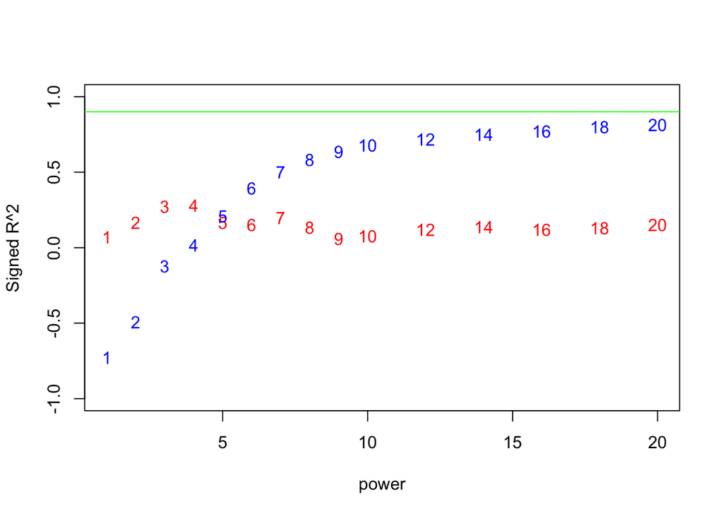

```r
plot(power, rep(0, length(power)), type = "n", ylab = "Signed R^2")
text(power, -sign(sft.x$fitIndices[,3])*sft.x$fitIndices[,2], labels = power, col = "red")
text(power, -sign(sft.y$fitIndices[,3])*sft.y$fitIndices[,2], labels = power, col = "blue")
abline(h = 0.90,col = "green")
```

```r
net.x = blockwiseModules(t(X), power = 1)
```

```
##      mergeCloseModules: less than two proper modules.
##       ..color levels are grey, turquoise
##       ..there is nothing to merge.
```

```r
net.y = blockwiseModules(t(Y), power = 20)

table(net.x$colors) # wrong signal in X
```

```
##
##      grey turquoise
##        12        22
```

```r
table(net.y$colors) # gene groups
```

```
##
##         bisque4           black            blue           brown
##              37             273             660             606
##          brown4            cyan       darkgreen        darkgrey
##              37             137              99              89
##     darkmagenta  darkolivegreen      darkorange     darkorange2
##              56              58              88              38
##         darkred   darkslateblue   darkturquoise     floralwhite
##             101              36              89              43
##           green     greenyellow            grey          grey60
##             442             172             482             120
##           ivory       lightcyan      lightcyan1      lightgreen
##              44             123              45             115
## lightsteelblue1     lightyellow         magenta          maroon
##              46             107             232              24
##   mediumpurple3    midnightblue    navajowhite2          orange
##              48             129              25              88
##      orangered4   paleturquoise  palevioletred3            pink
##              50              68              29             233
##           plum1           plum2          purple             red
##              51              34             188             436
##       royalblue     saddlebrown          salmon         salmon4
##             103              71             138              31
##         sienna3         skyblue        skyblue3       steelblue
##              56              71              54              68
##             tan        thistle1        thistle2       turquoise
##             170              33              33            1040
##          violet           white          yellow     yellowgreen
##              59              77             541              54
```

```r
# correlate eigen-genes of each group with true signal
sig_mes_cor <- cor(cbind(t(X[1:4, ]), net.y$MEs))[1:4, -c(1:4)]
(mes_select <- apply(sig_mes_cor, 1, which.max))
```

```
## T_4Nve T_8Nve T_4Mem T_8Mem
##     28     28     52     52
```

```r
plot(1:P0, rep(0, P0), type = "n", ylim = c(0, 1))
apply(X[1:2, ], 1, function(x) lines(1:P0, (x - min(x)) / (max(x) - min(x)), col = "red"))
```

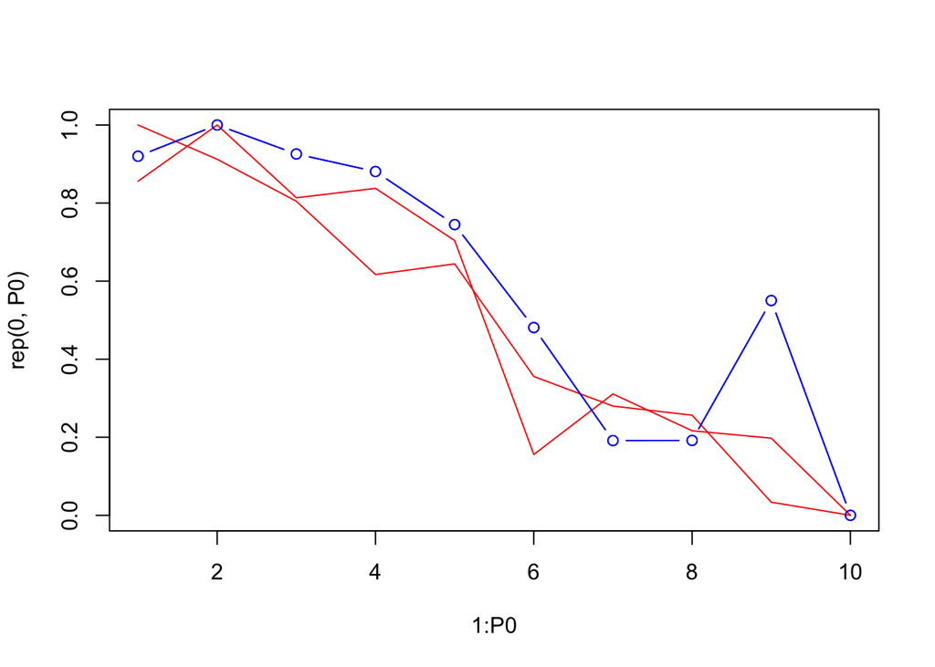

```r
apply(net.y$MEs[, mes_select[1:2]], 2, function(x) lines(1:P0, (x - min(x)) / (max(x) - min(x)), type = "b", col = "blue"))
```

```r
plot(1:P0, rep(0, P0), type = "n", ylim = c(0, 1))
apply(X[3:4, ], 1, function(x) lines(1:P0, (x - min(x)) / (max(x) - min(x)), col = "red"))
```

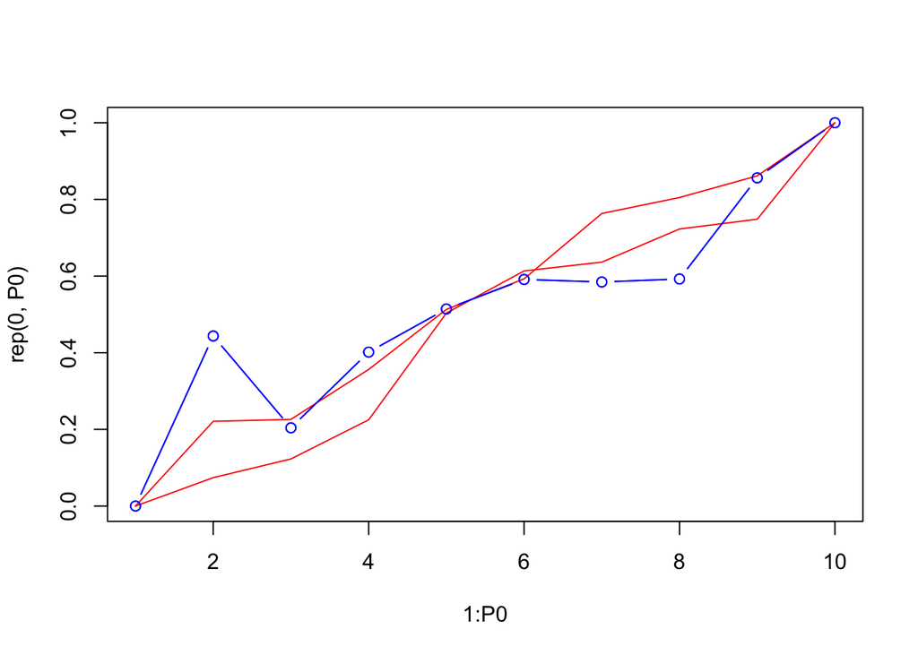

```r
apply(net.y$MEs[, mes_select[3:4]], 2, function(x) lines(1:P0, (x - min(x)) / (max(x) - min(x)), type = "b", col = "blue"))
```

##### PCA on each dataset

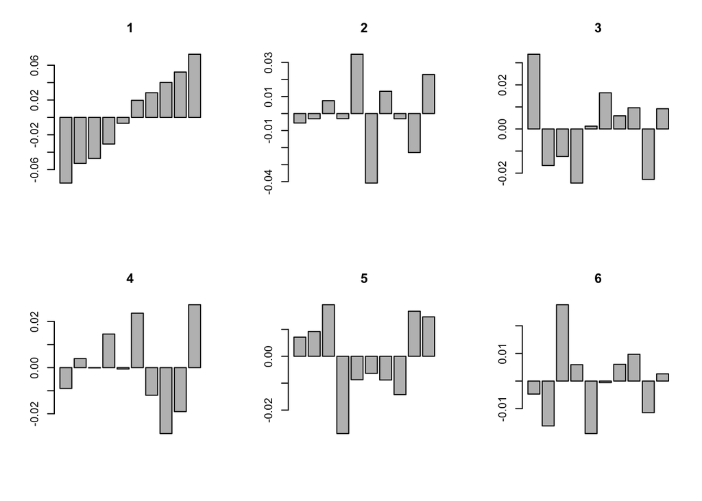

```r
svd.x <- svd(X - rowMeans(X))
svd.y <- svd(Y - rowMeans(Y))

pc.x <- diag(svd.x$d) %*% t(svd.x$v)
pc.y <- diag(svd.y$d) %*% t(svd.y$v)

par(mfrow = c(2, 3))
for(x in 1:6) barplot(pc.x[x, ], main = x)
```

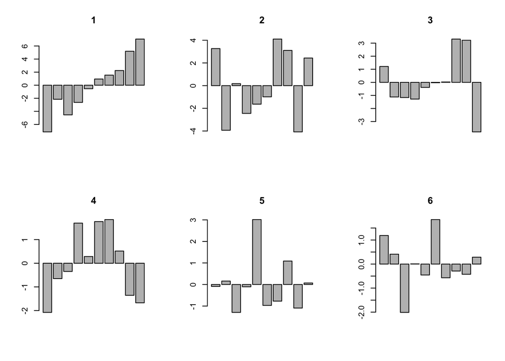

```r
for(x in 1:6) barplot(pc.y[x, ], main = x)
```

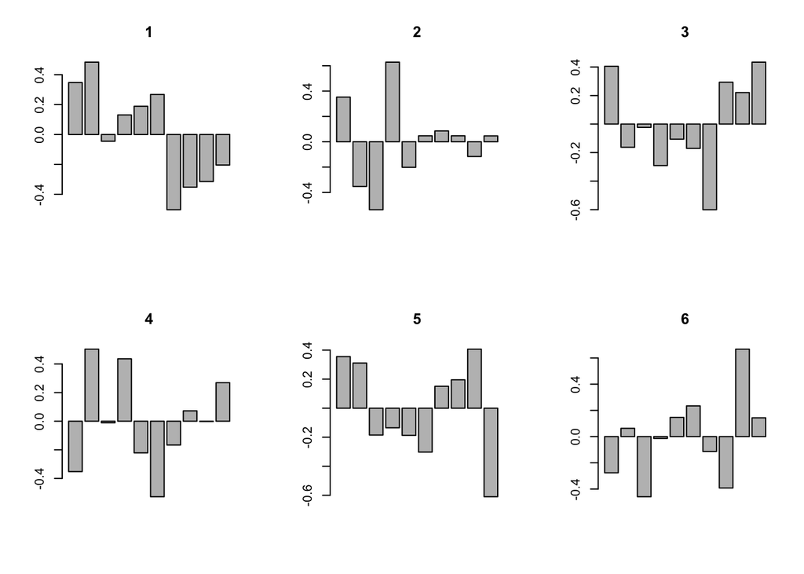

```r
Xm <- X[, c(9:10, 5:8, 1:4)] # shuffle the samples should not matter and indeed
svd.xm <- svd(Xm - rowMeans(Xm))
for(x in 1:6) barplot(svd.xm$v[, x], main = x)
```

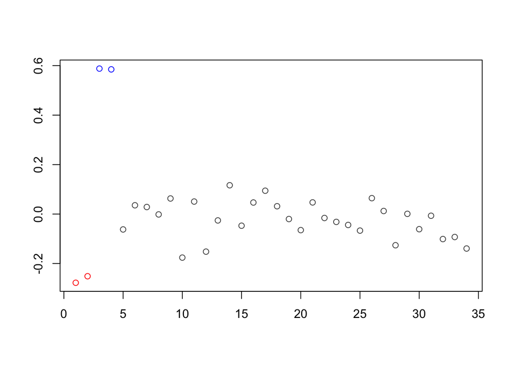

```r
par(mfrow = c(1, 1))
plot(svd.x$u[, 1], col = mycol, xlab = "", ylab = "")
```

```r
# first PC in X and Y concords well
# related top genes in svd.y$u are signatures of top cells in svd.x$u
```

# PCA the stacked datasets

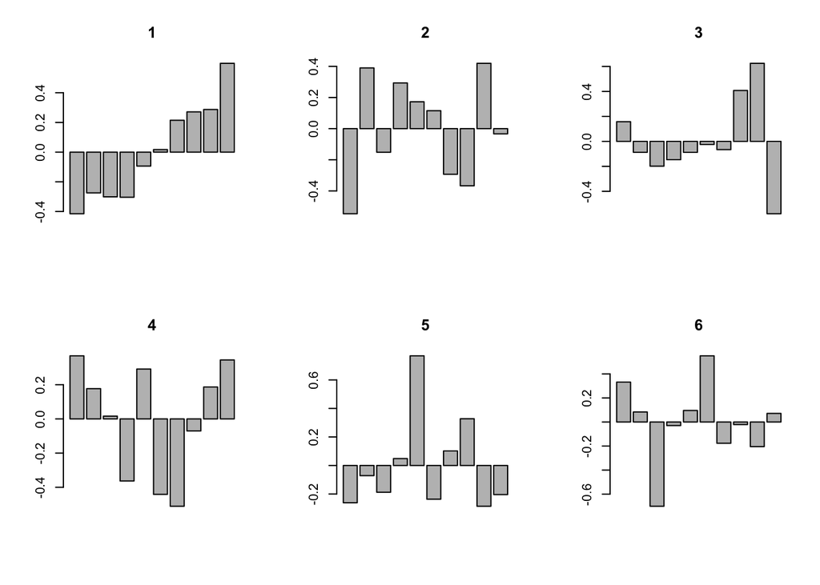

```r
scale.x = t(scale(t(X)))
scale.y = t(scale(t(Y)))
xy = rbind(scale.x, scale.y)
svd.xy = svd(xy)
pc.xy <- diag(svd.xy$d) %*% t(svd.xy$v)

par(mfrow = c(2, 3))
for(x in 1:6) barplot(svd.xy$v[, x], main = x)
```

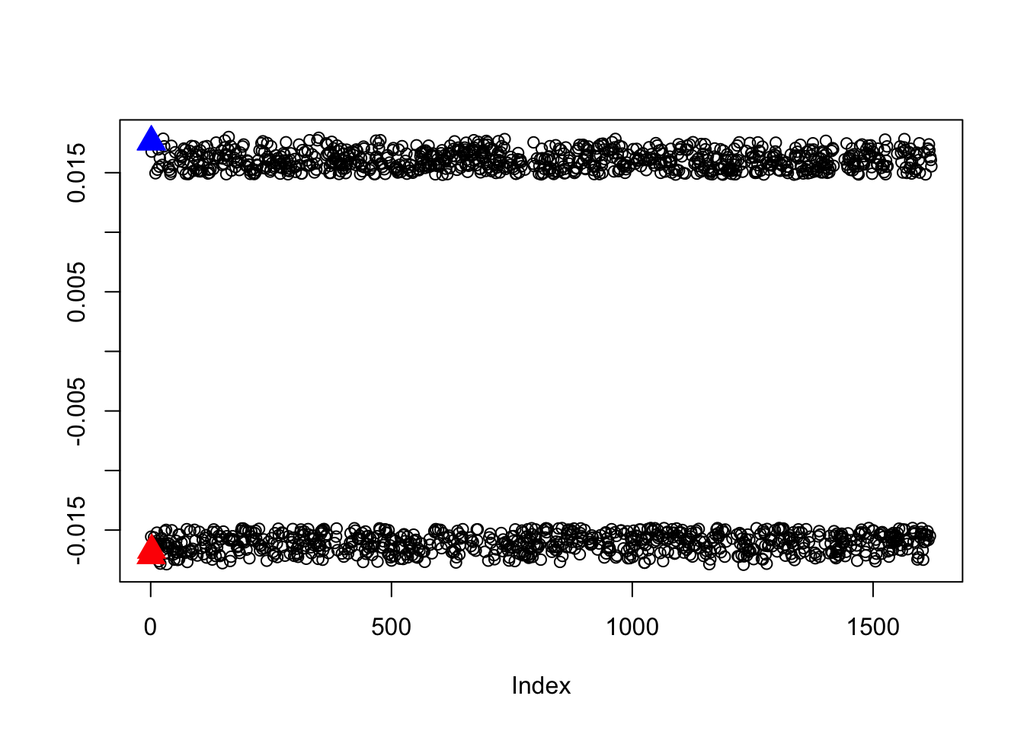

```r
# first PC is the true signal
# take top items in both ends of svd.xy$u, genes are signatures of related cells

u_signal <- svd.xy$u[, 1]; names(u_signal) <- rownames(xy)
cell_gene <- u_signal[abs(u_signal) > quantile(u_signal, 0.9)]

par(mfrow = c(1, 1))
plot(cell_gene[! grepl("_", names(cell_gene))], ylab = "") # all genes
points(cell_gene[grepl("^T_[48]Nve", names(cell_gene))], pch = 17, cex = 2, col = "red")
points(cell_gene[grepl("^T_[48]Mem", names(cell_gene))], pch = 17, cex = 2, col = "blue")
```

##### MCA method in Tan et al.

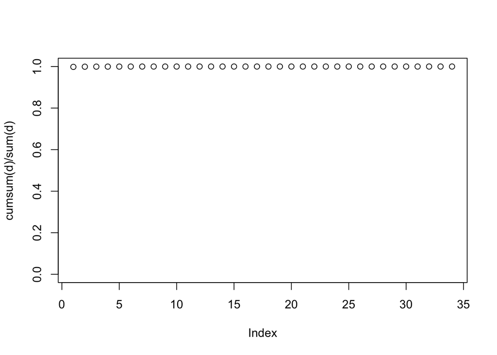

```r
Xp = X - rowMeans(X)
Yp = Y - rowMeans(Y)
C = X %*% t(Y) / (ncol(X) - 1)

svd.c = svd(C)
u = svd.c$u # left singular vector
v = svd.c$v # right signular vector
d = svd.c$d # cross-covariance

plot(cumsum(d)/sum(d), type = "b", ylim = c(0, 1))
```

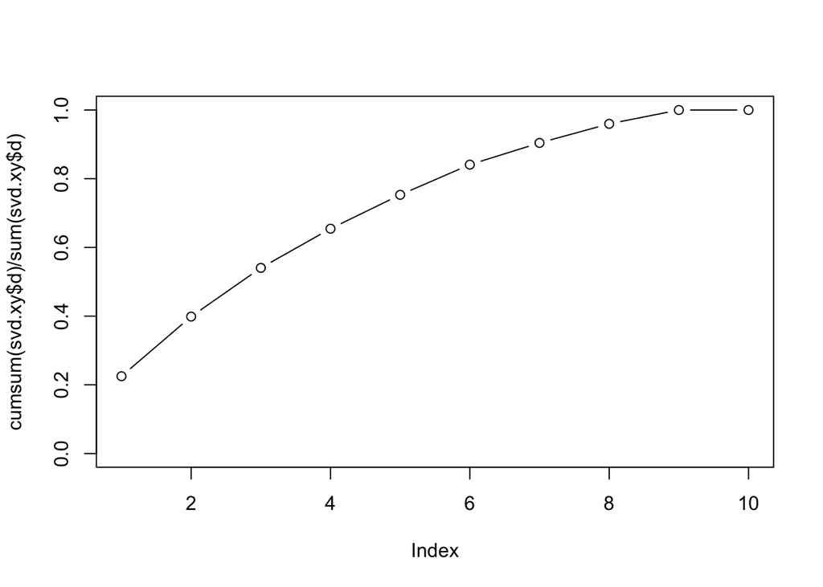

```r
plot(cumsum(svd.xy$d)/sum(svd.xy$d), type = "b", ylim = c(0, 1))
```

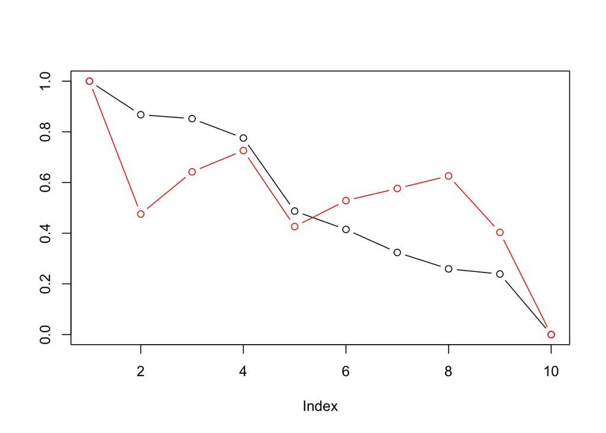

```r
# 1st variance explained all, this is striking contrast with variances of idependent PCA, make sensei, and argues for MCA

A = t(X) %*% u # projections of X onto u
B = t(Y) %*% v # projections of Y onto v

# A and B are linear combinations of X and Y, and vice versa
# total covariance of A and B are the same as total covariance of X and Y
# cov(A, B) is diagnal, and is largest in the first component

# Signular vectors (u, v) describe patterns of anomalies in each dataset that tend to occur simultaneously
# Coefficients (A, B) represent amplitudes of the respective patterns in each sample

plot((A[, 1] - min(A[, 1])) / (max(A[, 1] - min(A[, 1]))), type = "b", ylab = "")
lines((B[, 1] - min(B[, 1])) / (max(B[, 1] - min(B[, 1]))), type = "b", col = "red")
```

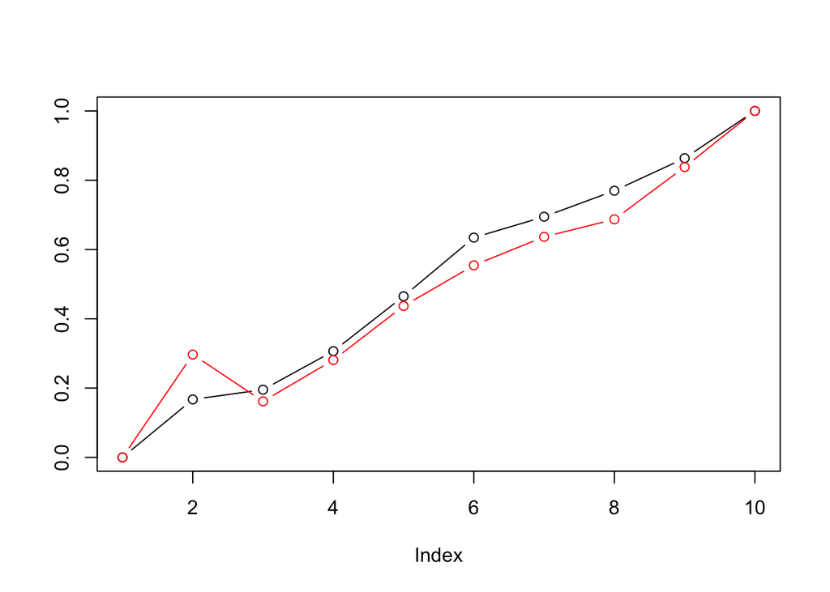

```r
plot((A[, 2] - min(A[, 2])) / (max(A[, 2] - min(A[, 2]))), type = "b", ylab = "")
lines((B[, 2] - min(B[, 2])) / (max(B[, 2] - min(B[, 2]))), type = "b", col = "red")
```

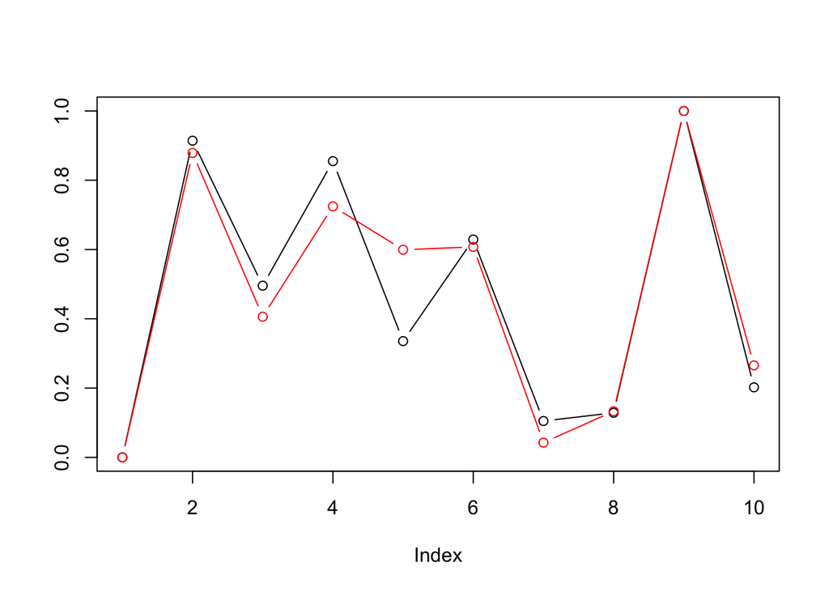

```r
plot((A[, 3] - min(A[, 3])) / (max(A[, 3] - min(A[, 3]))), type = "b", ylab = "")
lines((B[, 3] - min(B[, 3])) / (max(B[, 3] - min(B[, 3]))), type = "b", col = "red")
```

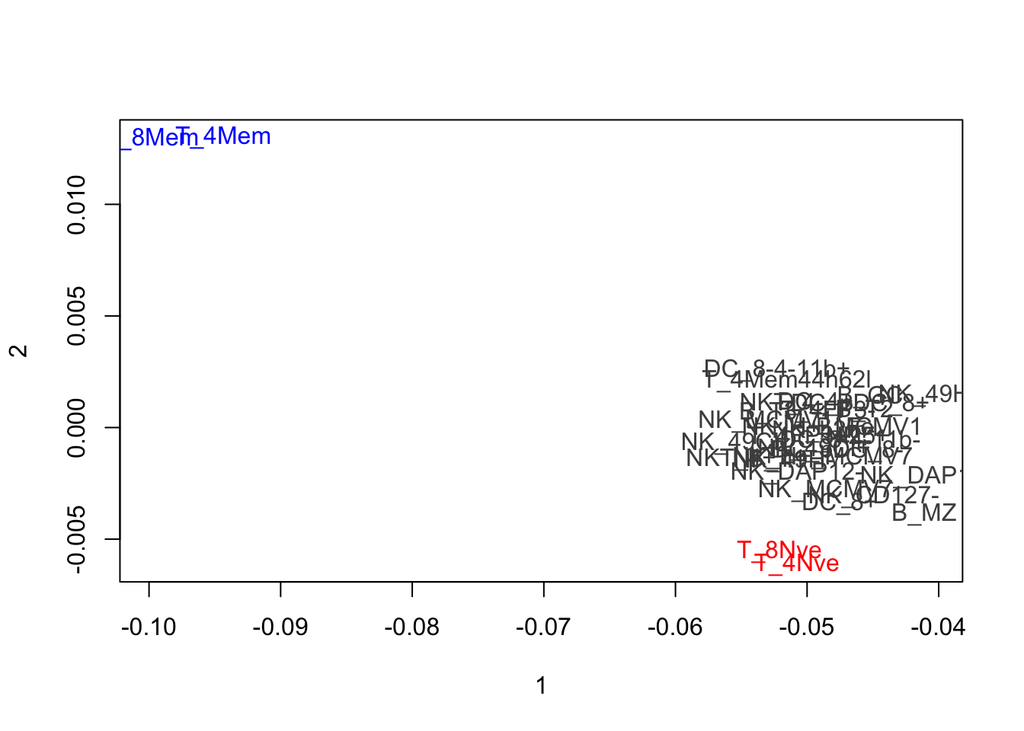

```r
# Mapping rows (X and Y) to principal components, yields weights of each gene in the new axis
Zx = X %*% A
Zy = Y %*% A # Robyn
Zy = Y %*% B # Classical

plot(Zx[, 1], Zx[, 2], type = "n", xlab = "1", ylab = "2")
text(Zx[, 1], Zx[, 2], rownames(Zx), col = mycol)
```

```r
# compute distances between Zx and Zy using the first two patterns

# graph.dt <- X[set1[, 1], ]
# graph.dt <- Y[set2[, 1], ]
# graph.dt <- t(scale(t(graph.dt)))
# graph.dt <- graph.dt - graph.dt[, 1]
#
# plot(1:59, rep(0, 59), type = "l", col = "blue", xlab = "", xaxt = "n", ylab = "", ylim = c(-5, 5))
# lapply(1:nrow(graph.dt), function(i) lines(graph.dt[i, ], type = "l", col = "grey30"))
# lines(colMeans(graph.dt), type = "b", lwd = 3, col = "red")
# axis(1, at=1:59, labels = 1:59)
```

### Thoughts

1. WGCNA: we need to know patterns in advance for the small dataset
2. PCA: first PCs works well for now, but what if noise level high? MCA’s first PC was impressive
3. PMCA to MCA, R has much to say